# Homework 2

Onur Can Aydın

07/05/2021

#INTRODUCTION AND MODEL CONSTRUCTION

That project is mainly focused on mortgaged sales in Izmir, what predictors we may use to forecast.After taking data from (https://evds2.tcmb.gov.tr/index.php?/evds/serieMarket) and brainstorming for predictors,we are able to check whether ‘Buying time condition of durable goods’ and ‘Interest Rate on Housing’,‘Exchange Rate’ and ‘Date’ are fit to be predictors of our model.Let us start with basic plot to observe.

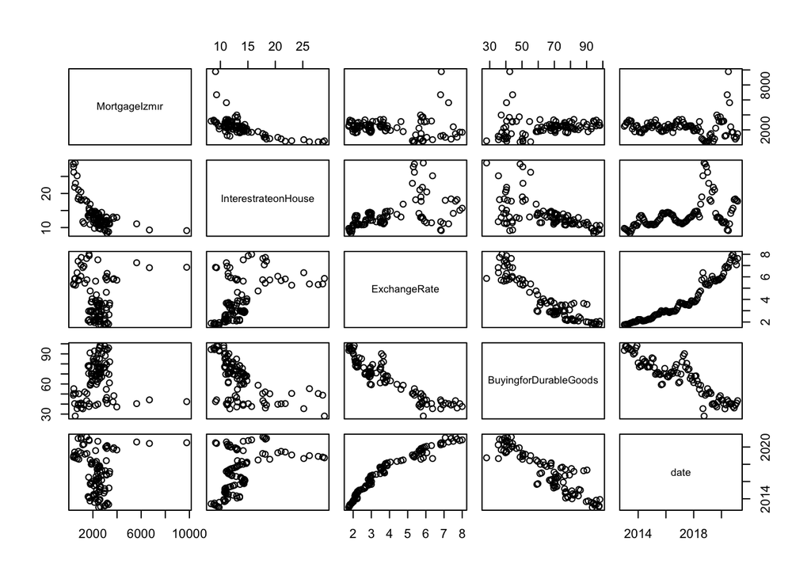

There’s been slight negative linearship between interest rate on housing and mortgaged sales can be observed.It ıs hard to tell another interpretation from these graphs.

In order to find another predictors or checking up on time-based parameters and manipulating data more easily,We plot graph of date and mortgaged sales.

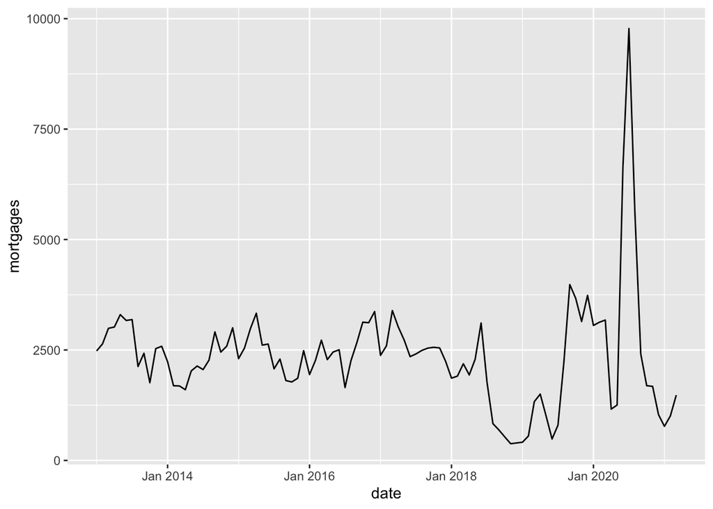

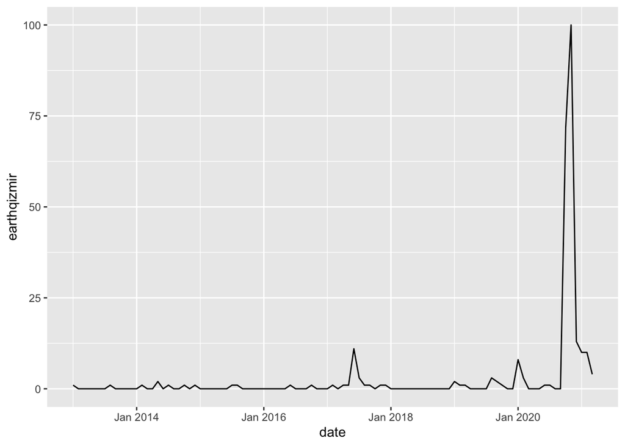

Sharp increases in both of graphs urges me to put these into model and test fitness of model.

```
##
## Call:
## lm(formula = mortgages ~ earthqizmir, data = mortgage)
##
## Residuals:
##     Min      1Q  Median      3Q     Max
## -2010.3  -596.3    19.7   433.1  7398.5
##
## Coefficients:
##             Estimate Std. Error t value Pr(>|t|)
## (Intercept)  2388.31     127.94  18.668   <2e-16 ***
## earthqizmir    -9.86      10.12  -0.974    0.332
## ---
## Signif. codes:  0 '***' 0.001 '**' 0.01 '*' 0.05 '.' 0.1 ' ' 1
##
## Residual standard error: 1244 on 97 degrees of freedom
## Multiple R-squared:  0.009687,   Adjusted R-squared:  -0.0005223
## F-statistic: 0.9488 on 1 and 97 DF,  p-value: 0.3324
```

The p value of model is not small enough for good model.As another way,building model with earthquake factor variable could make more sense.Then ,we shall build with factor variable and check that model.

```
##
## Call:
## lm(formula = mortgages ~ as.factor(is_earth), data = mortgage)
##
## Residuals:
##     Min      1Q  Median      3Q     Max
## -1991.1  -594.6     8.9   447.4  7407.9
##
## Coefficients:
##                      Estimate Std. Error t value Pr(>|t|)
## (Intercept)            2369.1      126.8  18.679   <2e-16 ***
## as.factor(is_earth)1   -356.1      892.3  -0.399    0.691
## ---
## Signif. codes:  0 '***' 0.001 '**' 0.01 '*' 0.05 '.' 0.1 ' ' 1
##
## Residual standard error: 1249 on 97 degrees of freedom
## Multiple R-squared:  0.001639,   Adjusted R-squared:  -0.008653
## F-statistic: 0.1593 on 1 and 97 DF,  p-value: 0.6907
```

In spite of similar plot,that variable did not make sense,which is logical to exclude that variable.

Let us construct model with interest rate on housing which gives slight linearship in first plot.Then,we shall check residuals.

```
##
## Call:
## lm(formula = mortgages ~ intrateonhouse, data = mortgage)
##
## Residuals:
##     Min      1Q  Median      3Q     Max
## -1578.9  -450.4  -162.1   143.8  6553.2
##
## Coefficients:
##                Estimate Std. Error t value Pr(>|t|)
## (Intercept)     4912.85     329.46  14.912  < 2e-16 ***
## intrateonhouse  -185.41      22.88  -8.102 1.63e-12 ***
## ---
## Signif. codes:  0 '***' 0.001 '**' 0.01 '*' 0.05 '.' 0.1 ' ' 1
##
## Residual standard error: 965.5 on 97 degrees of freedom
## Multiple R-squared:  0.4036, Adjusted R-squared:  0.3975
## F-statistic: 65.64 on 1 and 97 DF,  p-value: 1.628e-12
```

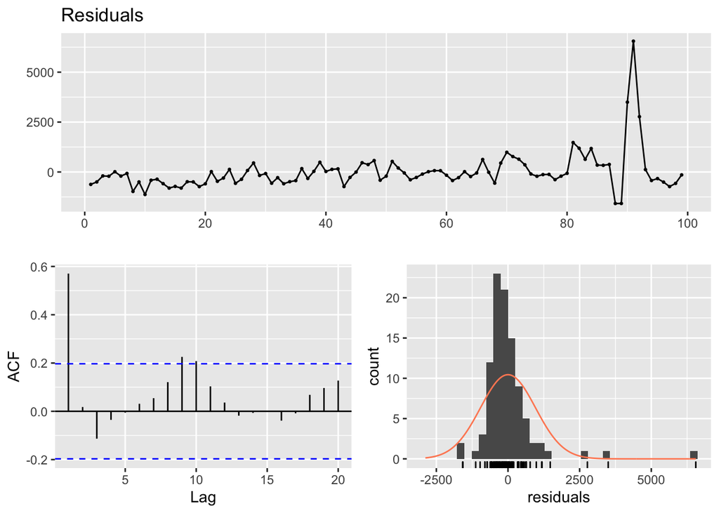

```
##
##  Breusch-Godfrey test for serial correlation of order up to 10
##
## data:  Residuals
## LM test = 57.528, df = 10, p-value = 1.06e-08
```

That model is much better compared to first two model.However,autocorrelation values ,residuals are a little distrubant.We come to that later.

Putting other potential variables into model could make model better.We may start with buying time condition for durable goods.Check residuals as well.

```
##
## Call:
## lm(formula = mortgages ~ intrateonhouse + buyconfordurable, data = mortgage)
##
## Residuals:
##     Min      1Q  Median      3Q     Max
## -2425.1  -379.0  -108.0   305.8  5718.6
##
## Coefficients:
##                  Estimate Std. Error t value Pr(>|t|)
## (Intercept)      7310.531    669.025  10.927  < 2e-16 ***
## intrateonhouse   -246.174     26.073  -9.442 2.35e-15 ***
## buyconfordurable  -23.803      5.905  -4.031 0.000111 ***
## ---
## Signif. codes:  0 '***' 0.001 '**' 0.01 '*' 0.05 '.' 0.1 ' ' 1
##
## Residual standard error: 897.5 on 96 degrees of freedom
## Multiple R-squared:  0.4899, Adjusted R-squared:  0.4793
## F-statistic: 46.11 on 2 and 96 DF,  p-value: 9.247e-15
```

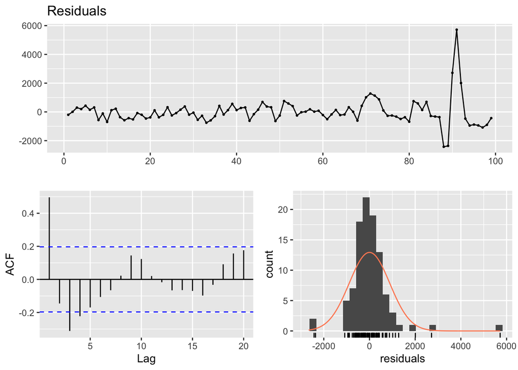

```
##
##  Breusch-Godfrey test for serial correlation of order up to 10
##
## data:  Residuals
## LM test = 52.997, df = 10, p-value = 7.457e-08
```

This variable is logical to hold in the model.Not only the p value of that predictor but also new residuals graph are reasons for our new model to be better.

Even if exchange rate does not seem nice predictor in our first plot.It is better to check up on that variable as numeric result in another model.

```
##
## Call:
## lm(formula = mortgages ~ intrateonhouse + buyconfordurable +
##     exchangerate, data = mortgage)
##
## Residuals:
##     Min      1Q  Median      3Q     Max
## -2425.3  -343.2  -108.2   245.8  5640.8
##
## Coefficients:
##                  Estimate Std. Error t value Pr(>|t|)
## (Intercept)       6021.21    1463.97   4.113 8.31e-05 ***
## intrateonhouse    -243.08      26.26  -9.256 6.43e-15 ***
## buyconfordurable   -12.35      12.99  -0.951    0.344
## exchangerate       124.56     125.80   0.990    0.325
## ---
## Signif. codes:  0 '***' 0.001 '**' 0.01 '*' 0.05 '.' 0.1 ' ' 1
##
## Residual standard error: 897.6 on 95 degrees of freedom
## Multiple R-squared:  0.4951, Adjusted R-squared:  0.4792
## F-statistic: 31.06 on 3 and 95 DF,  p-value: 4.431e-14
```

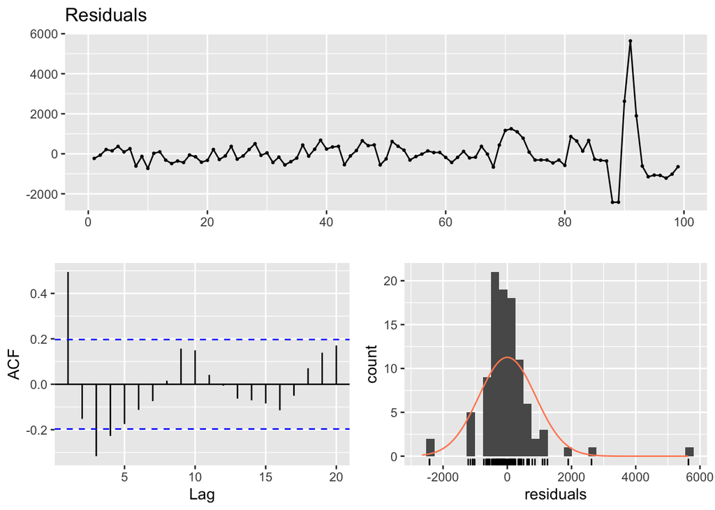

```
##
##  Breusch-Godfrey test for serial correlation of order up to 10
##
## data:  Residuals
## LM test = 57.656, df = 10, p-value = 1.003e-08
```

As we guessed above,that is not going to be one of our independent variables,which is better to take it out of model.

From the beggining of our first model,autocorrelation values are disturbant.Then,lag variable could take place in the model, which is able to be better for autocorrelation.

```
##
## Call:
## lm(formula = mortgages ~ intrateonhouse + buyconfordurable +
##     lag.value, data = mortgage)
##
## Residuals:
##     Min      1Q  Median      3Q     Max
## -2293.0  -365.3   -11.7   219.6  4562.9
##
## Coefficients:
##                   Estimate Std. Error t value Pr(>|t|)
## (Intercept)      4471.4202   824.7706   5.421 4.48e-07 ***
## intrateonhouse   -155.8420    29.4948  -5.284 8.03e-07 ***
## buyconfordurable  -14.4613     5.6018  -2.582   0.0114 *
## lag.value           0.4152     0.0830   5.002 2.60e-06 ***
## ---
## Signif. codes:  0 '***' 0.001 '**' 0.01 '*' 0.05 '.' 0.1 ' ' 1
##
## Residual standard error: 802.7 on 95 degrees of freedom
## Multiple R-squared:  0.5963, Adjusted R-squared:  0.5835
## F-statistic: 46.77 on 3 and 95 DF,  p-value: < 2.2e-16
```

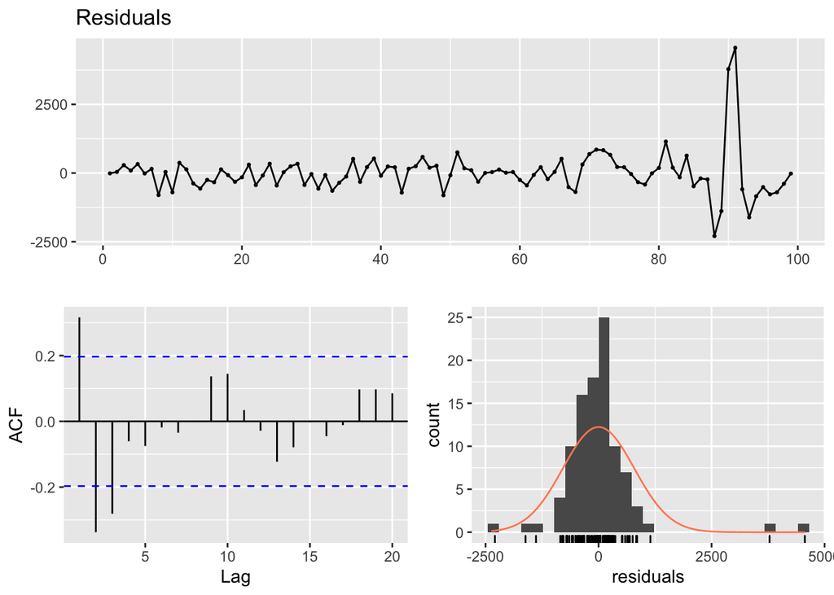

```
##
##  Breusch-Godfrey test for serial correlation of order up to 10
##
## data:  Residuals
## LM test = 45.551, df = 10, p-value = 1.729e-06
```

Now, autocorrelation seems better off. With our current model,We may find fit values and attach them to our model.For first impression, we may see plot of residuals and fitted values below.

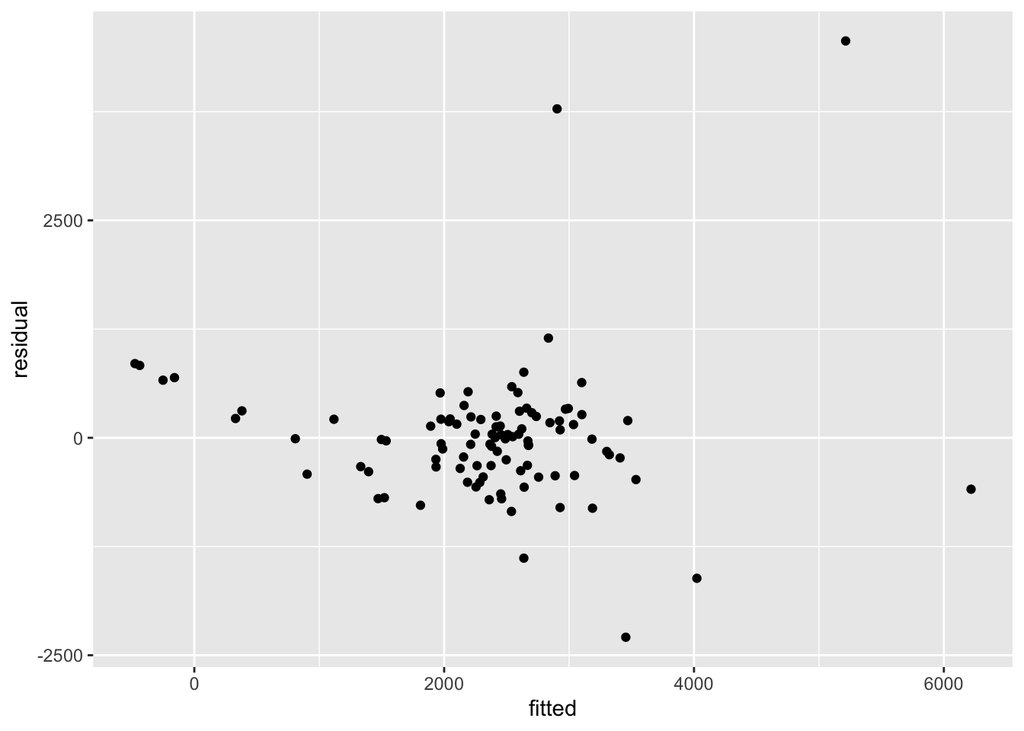

That plot indicates that there is no big variance or serious dependency between residuals except some of outliers.

Comparison of fitted values and real observations is crucial.Then,plot them below.

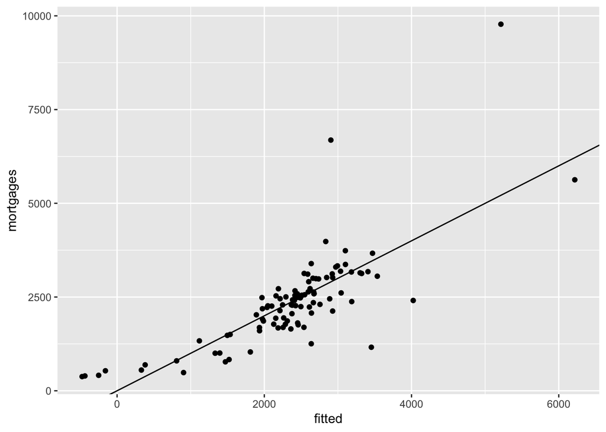

That seems acceptable.

#Forecasting

Given data including mortgaged sales values until March 2021,We try to forecast next month,which means extending our data.

```
##     Point Forecast    Lo 80    Hi 80     Lo 95    Hi 95
## 100       17.74003 15.74905 19.73100 14.695096 20.78495
## 101       17.74003 14.91911 20.56094 13.425814 22.05424
## 102       17.74003 14.27856 21.20149 12.446173 23.03388
## 103       17.74003 13.73543 21.74462 11.615526 23.86452
## 104       17.74003 13.25417 22.22588 10.879497 24.60055
## 105       17.74003 12.81657 22.66348 10.210253 25.26980
## 106       17.74003 12.41185 23.06820  9.591286 25.88876
## 107       17.74003 12.03299 23.44706  9.011862 26.46819
## 108       17.74003 11.67511 23.80494  8.464536 27.01551
## 109       17.74003 11.33468 24.14537  7.943898 27.53615
```

```
##     Point Forecast    Lo 80    Hi 80     Lo 95    Hi 95
## 100       43.34977 36.23682 50.46271 32.471453 54.22808
## 101       43.34977 33.29104 53.40849 27.966279 58.73325
## 102       43.34977 31.03060 55.66893 24.509235 62.19030
## 103       43.34977 29.12494 57.57459 21.594776 65.10475
## 104       43.34977 27.44601 59.25352 19.027070 67.67246
## 105       43.34977 25.92813 60.77140 16.705676 69.99385
## 106       43.34977 24.53230 62.16724 14.570929 72.12860
## 107       43.34977 23.23308 63.46645 12.583950 74.11558
## 108       43.34977 22.01283 64.68670 10.717736 75.98179
## 109       43.34977 20.85868 65.84085  8.952624 77.74691
```

```
##     Point Forecast      Lo 80    Hi 80      Lo 95    Hi 95
## 100       1005.977  -259.0373 2270.991  -928.6952 2940.648
## 101       1005.977  -782.9338 2794.887 -1729.9257 3741.879
## 102       1005.977 -1184.9457 3196.899 -2344.7499 4356.703
## 103       1005.977 -1523.8615 3535.815 -2863.0768 4875.030
## 104       1005.977 -1822.4542 3834.407 -3319.7350 5331.688
## 105       1005.977 -2092.4038 4104.357 -3732.5872 5744.540
## 106       1005.977 -2340.6487 4352.602 -4112.2451 6124.198
## 107       1005.977 -2571.7100 4583.663 -4465.6228 6477.576
## 108       1005.977 -2788.7278 4800.681 -4797.5229 6809.476
## 109       1005.977 -2993.9886 5005.942 -5111.4422 7123.395
```

We predicted values of independent variables first.After that,we forecast value for April 2021,which is 2489.702.It is time to plot our real and fitted values in line graph.

```
## [1] 2489.702
```

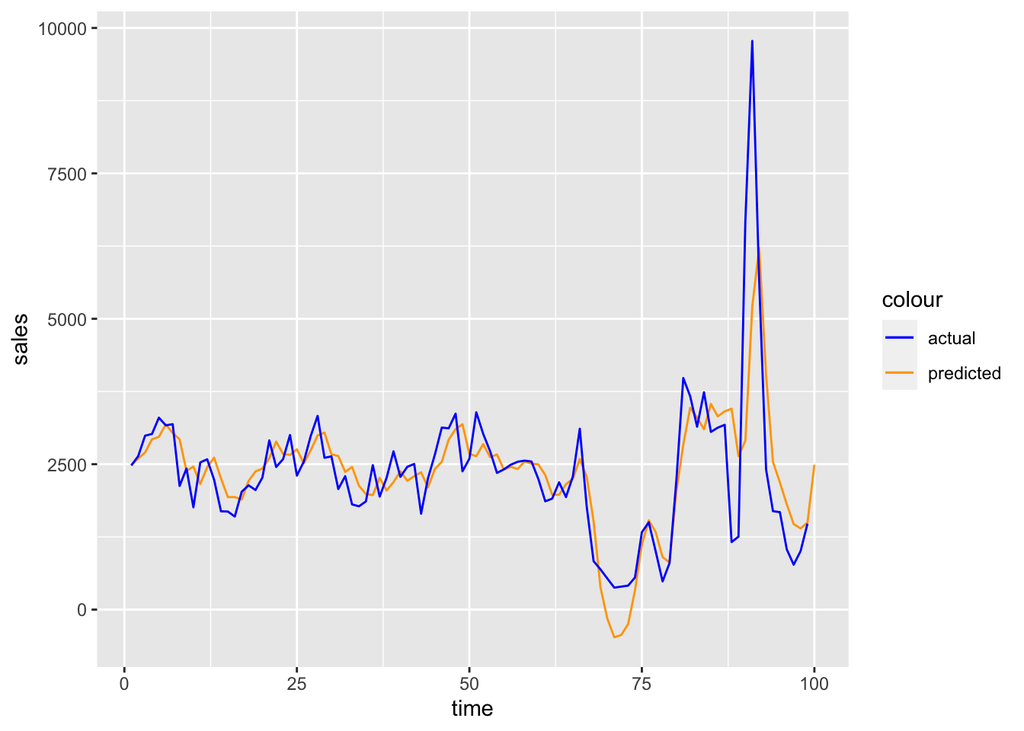

#CONCLUSION

Mortgaged sales in Izmir is related to Buying time condition of durable goods ,Interest Rate on Housing and lag variables that is really beneficial to avoid autocorrelation after observing multiple models based on p values and taking out of worse ones.We provided predicted value of April 2021 that is 2489.702 and plot of real and expected ones at last.